# Prevendo Mercado de ações global com apredizado de máquina

**Aluno: Nicholas Richers**

*Orientador: Carlos Alberto Nunes Cosenza*

[figure not shown]

# Introdução

## Apresentação do problema

O problema de predição de preços de ações é **muito difícil**, há anos fundos quantitativos tentam abordar esse problema, porém **nem sempre com sucesso**.

[figure not shown]

*Fonte: https://www.barrons.com/articles/quant-funds-struggled-in-2019-the-outlook-for-this-year-is-more-of-the-same-51579782601*

### A realidade para alguns outros é diferente

```python
from IPython.display import YouTubeVideo
YouTubeVideo('mC-lRrO0JWg', width=700, height=400)
```

[video not shown]

### Usar Machine Learning apenas nao resolve

```python
from IPython.display import YouTubeVideo
YouTubeVideo('BRUlSm4gdQ4', width=700, height=400)
```

[video not shown]

## Descrição do Problema

Uma das causas desse problema é que há uma altíssima **barreira de entrada** para a **pesquisa aplicada** nessa área, são elas:

1. A primeira barreira seria **dominar todas as áreas** relacionadas e necessárias para elaborar uma estratégia de investimentos.
2. Restrições orçamentárias limitam o **tamanho de uma equipe**. Isso é um problema, porque uma equipe enxuta de pesquisadores tem amplitude limitada.
3. Direitos de **confidencialidade do provedor dados** impede que esses dados sejam disponibilidados publicamente.
4. Incentivo a **falsos positivos**. Pesquisadores são remunerados para produzir **simulações** de estratégias de investimentos **com resultados promissores** em um conjunto de dados limitado, levando a um **viés de seleção** (*overfitting*).

*Fonte: DE PRADO, M. L., FABOZZI, F. J. “Crowdsourced Investment Research Through Tournaments”, The Journal of Financial Data Science, v. 2, n. 1, pp. 86–93, 2020.*

### Uma Alternativa para o problema

De Prado (2020), sugere a formação de um **torneio**, onde um **organizador formaliza** um desafio de estratégias investimento em **termos de um problema preditivo**, para incentivar a **pesquisa** de maneira **coletiva**.

Os torneios dividem o problema de estratégias investimento em **duas tarefas especializadas**:

- i. **Estruturar os dados** de forma a constituir um problema preditivo, que é executada pelos **organizadores** do torneio, que possuem extenso **conhecimento em finanças**;
- ii. **Modelagem**, que é feita pelos **participantes** do torneio com conhecimento de **ciência de dados**.

### Como Suplantar as barreiras através do torneio

1. Como o problema de previsão já foi definido os **participantes** do torneio podem trabalhar nesse desafio **mesmo que não possuam conhecimento em finanças**.
2. O torneio é acessível a **ampla comunidade de cientistas de dados**.
3. A confidencialidade é resolvida **ofuscando ou encriptando** os dados de forma a preservar as propriedades matemáticas essencial para um problema preditivo.
4. O overfitting é mitigado **remunerando os pesquisadores através do desempenho fora da amostra**. Além disso os pesquisados são **incentivados a apostar o próprio dinheiro em suas previsões**.

*Fonte: DE PRADO, M. L., FABOZZI, F. J. “Crowdsourced Investment Research Through Tournaments”, The Journal of Financial Data Science, v. 2, n. 1, pp. 86–93, 2020.*

## Esse Torneio já existe

### Modelos de torneio existentes

1. *Numerai Signals*: Os competidores são livres para usar **qualquer tipo de dados que dispuserem** referentes a uma **cesta de 5000 ações divulgadas** de forma explícita. A partir dos próprios dados devem **treinar um modelo preditivo** capaz de prever o comportamento de cada dessas ações no futuro.
2. *Numerai Tournament*: Essa é a **competição principal**, configurada exatamente da forma descrita por De Prado (2020), usando os **dados encriptados** disponibilizados pela **equipe da numerai** e as predições são feitas nos **mesmas ações da Numerai Signals**, porém **anonimizados**.

## Numerai Signals

Nesta seção vamos ilustrar um **exemplo básico** de como criar previsões para o numerai signals, e suas **semelhanças** com o numerai tournament.

### Ao entrar no torneio recebemos uma lista de ações toda semana para fazermos as predições

```python
# read in list of active Signals tickers which can change slightly era to era
napi = numerapi.SignalsAPI(NAPI_PUBLIC_KEY, NAPI_PRIVATE_KEY)
eligible_tickers = pd.Series(napi.ticker_universe(), name='ticker')
eligible_tickers
```

```
0       316140 KS
1       000060 KS
2       000080 KS
3       000100 KS
4       000120 KS
          ...
4828      LIVX US
4829      ASPN US
4830        CG US
4831        GO US
4832      IMUX US
Name: ticker, Length: 4833, dtype: object
```

### Esses Valores se referem ao bloomberg ticker

[figure not shown]

*Fonte: https://www.bloomberg.com/quote/IMUX:US*

#### Distribuição das ações por país

[figure not shown]

#### Distribuição das ações por segmento

[figure not shown]

### Definindo o problema preditivo

Vamos obter o **preço de fechamento diário** dessas ações de **dezembro de 2002** até a data presente usando o **yahoo finance**, um provedor de dados **gratuito** bastante conhecido.

```python
print("Series lenght: {} values", full_data.shape[0]) #16409633
```

[output not shown]

```python
# properly position and clean raw data, after taking adjusted close only
full_data.columns = ['date', 'ticker', 'price']
full_data.set_index('date', inplace=True)

# convert yahoo finance tickers back to numerai tickers
full_data['ticker'] = full_data.ticker.map(dict(zip(yfinance_tickers, numerai_tickers)))

print(f"Number of tickers with data: {len(full_data.ticker.unique())}")
full_data.head()
```

```
Number of tickers with data: 4947
```

| date | ticker | price |
| --- | --- | --- |
| 2002-12-02 | 1723 NA | 20.359694 |
| 2002-12-02 | 2352 NA | 32667.400391 |
| 2002-12-02 | 139480 KS | 14.597309 |
| 2002-12-02 | 1316 HK | 1.459269 |
| 2002-12-02 | 1605 JP | 1.101638 |

### Adicionando Indicadores ao modelo

Agora que já temos os preços, precisamos configurar **indicadores** que adicionem **valor preditivo** ao modelo.

#### Índice de Força Relativa (RSI):

O RSI é um indicadorde **análise técnica** que busca medir se o ativo está **excessivamente vendido (RSI>70)** ou **excessivamente comprado (RSI<30)**.

$$RSI = 100 - (100/(1 + RS))$$

*RS = Média dos retornos nos períodos de alta / Média dos retornos nos períodos de baixa*

*Fonte: WILDER, J.New Concepts in Technical Trading Systems. Trend Research, 1978*

### Configurando o indicador

Modelos de Machine learning funcionam bem com dados distribuídos na forma de **histograma**. Aqui faremos uma divisão em 5 bins.

```python
# group by era (date) and create quintile labels within each era, useful for learning relative ranking

ticker_groups = full_data.groupby('ticker')
full_data['RSI'] = ticker_groups['price'].transform(lambda x: RSI(x))

date_groups = full_data.groupby(full_data.index)
full_data['RSI_quintile'] = date_groups['RSI'].transform(lambda group:pd.qcut(group,5,False, duplicates='drop'))
full_data.dropna(inplace=True)

full_data.head()
```

| date | ticker | price | RSI | RSI_quintile |
| --- | --- | --- | --- | --- |
| 2002-12-20 | 1723 NA | 18.581551 | 18.748923 | 0.0 |
| 2002-12-20 | 2352 NA | 33711.300781 | 70.729613 | 4.0 |
| 2002-12-20 | 139480 KS | 14.736325 | 58.823245 | 4.0 |
| 2002-12-20 | 1316 HK | 1.445166 | 45.453015 | 3.0 |
| 2002-12-20 | 1605 JP | 1.038018 | 36.231858 | 2.0 |

### Engenharia de Features

Vamos aumentar o valor preditivo dessa variável adicionando o RSI dos **períodos anteriores**

```python
ticker_groups = full_data.groupby('ticker')

#create lagged features, lag 0 is that day's value, lag 1 is yesterday's value, etc
num_days = 5
for day in range(num_days+1):
    full_data[f'RSI_quintile_lag_{day}']=ticker_groups['RSI_quintile'].transform(lambda group: group.shift(day))

full_data.tail()
```

| date | ticker | price | RSI | RSI_quintile | RSI_quintile_lag_0 | RSI_quintile_lag_1 | RSI_quintile_lag_2 | RSI_quintile_lag_3 | RSI_quintile_lag_4 | RSI_quintile_lag_5 |
| --- | --- | --- | --- | --- | --- | --- | --- | --- | --- | --- |
| 2020-10-12 | MNKD US | 168.720001 | 64.311255 | 2.0 | 2.0 | 2.0 | 2.0 | 1.0 | 2.0 | 3.0 |
| 2020-10-12 | TXT US | 31.469999 | 72.376548 | 3.0 | 3.0 | 3.0 | 2.0 | 1.0 | 1.0 | 0.0 |
| 2020-10-12 | SAF FP | 10.980000 | 65.399234 | 2.0 | 2.0 | 2.0 | 3.0 | 3.0 | 3.0 | 3.0 |
| 2020-10-12 | CAST SS | 322.200012 | 41.706164 | 0.0 | 0.0 | 0.0 | 0.0 | 0.0 | 0.0 | 0.0 |
| 2020-10-12 | TDG US | 15.160000 | 41.411559 | 0.0 | 0.0 | 3.0 | 3.0 | 4.0 | 4.0 | 4.0 |

### Adicionado ainda mais informação

```python
# create difference of the lagged features (change in RSI quintile by day)
for day in range(num_days):
    full_data[f'RSI_diff_{day}'] = full_data[f'RSI_quintile_lag_{day}'] - full_data[f'RSI_quintile_lag_{day+1}']
    full_data[f'RSI_abs_diff_{day}']=np.abs(full_data[f'RSI_quintile_lag_{day}'] - full_data[f'RSI_quintile_lag_{day + 1}'])

full_data.tail()
```

| date | ticker | price | RSI | RSI_quintile | RSI_quintile_lag_0 | RSI_quintile_lag_1 | RSI_quintile_lag_2 | RSI_quintile_lag_3 | RSI_quintile_lag_4 | RSI_quintile_lag_5 | RSI_diff_0 | RSI_abs_diff_0 | RSI_diff_1 | RSI_abs_diff_1 | RSI_diff_2 | RSI_abs_diff_2 | RSI_diff_3 | RSI_abs_diff_3 | RSI_diff_4 | RSI_abs_diff_4 |
| --- | --- | --- | --- | --- | --- | --- | --- | --- | --- | --- | --- | --- | --- | --- | --- | --- | --- | --- | --- | --- |
| 2020-10-12 | MNKD US | 168.720001 | 64.311255 | 2.0 | 2.0 | 2.0 | 2.0 | 1.0 | 2.0 | 3.0 | 0.0 | 0.0 | 0.0 | 0.0 | 1.0 | 1.0 | -1.0 | 1.0 | -1.0 | 1.0 |
| 2020-10-12 | TXT US | 31.469999 | 72.376548 | 3.0 | 3.0 | 3.0 | 2.0 | 1.0 | 1.0 | 0.0 | 0.0 | 0.0 | 1.0 | 1.0 | 1.0 | 1.0 | 0.0 | 0.0 | 1.0 | 1.0 |
| 2020-10-12 | SAF FP | 10.980000 | 65.399234 | 2.0 | 2.0 | 2.0 | 3.0 | 3.0 | 3.0 | 3.0 | 0.0 | 0.0 | -1.0 | 1.0 | 0.0 | 0.0 | 0.0 | 0.0 | 0.0 | 0.0 |
| 2020-10-12 | CAST SS | 322.200012 | 41.706164 | 0.0 | 0.0 | 0.0 | 0.0 | 0.0 | 0.0 | 0.0 | 0.0 | 0.0 | 0.0 | 0.0 | 0.0 | 0.0 | 0.0 | 0.0 | 0.0 | 0.0 |
| 2020-10-12 | TDG US | 15.160000 | 41.411559 | 0.0 | 0.0 | 3.0 | 3.0 | 4.0 | 4.0 | 4.0 | -3.0 | 3.0 | 0.0 | 0.0 | -1.0 | 1.0 | 0.0 | 0.0 | 0.0 | 0.0 |

### A Variável Alvo (Target)

- A numerai é responsável por disponibilizar a variável alvo para cada ativo, para a próxima era. Uma era começa toda **sexta-feira** e será baseada nos **retornos dos dias subsequentes**.
- A variável alvo é configurada como um problema de **classificação**, **normalizadas e neutralizadas** dos retornos dentro de **cada era**.

```python
# read in Signals targets
numerai_targets = 'https://numerai-signals-public-data.s3-us-west-2.amazonaws.com/signals_train_val.csv'
targets = pd.read_csv(numerai_targets)
targets['date'] = pd.to_datetime(targets['friday_date'], format='%Y%m%d')

targets.head().style.set_properties(**{'font-size': '14pt'})
```

|  | ticker | friday_date | data_type | target | date |
| --- | --- | --- | --- | --- | --- |
| 0 | 000270 KS | 20030131 | train | 0.500000 | 2003-01-31 00:00:00 |
| 1 | 000810 KS | 20030131 | train | 0.500000 | 2003-01-31 00:00:00 |
| 2 | 000830 KS | 20030131 | train | 0.500000 | 2003-01-31 00:00:00 |
| 3 | 002790 KS | 20030131 | train | 0.250000 | 2003-01-31 00:00:00 |
| 4 | 003450 KS | 20030131 | train | 0.250000 | 2003-01-31 00:00:00 |

```python
print("Series lenght: {} values".format(targets.shape[0]))

print(f'Number of eras in data: {len(ML_data.index.unique())}')
```

```
Series lenght: 4043435 values
Number of eras in data: 851
```

### A distribuição do target

O target assume valores de {0, 0,25, 0,5, 0,75, 1}, mas as classes são **desbalanceadas**

- 10% dos valores assumem 0 ou 1.
- 40% dos valores assumem 0,25 ou 0,75.
- 50% dos valores assumem 0,5.

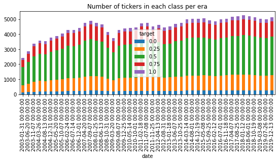

```python
pivot_target = targets.groupby(['date','target']).apply(lambda x: len(x)).reset_index(1).pivot(columns='target',values=0)
pivot_target.iloc[::20].plot(kind='bar', stacked=True, figsize=(9,3), title='Number of tickers in each class per era')
```

### Combinando os nossos dados com o target

Aqui iremos juntar os dados que coletanos de **provedores externos**, com o **target** fornecido pela **numerai**.

```python
ML_data.head()
```

| date | ticker | price | RSI | RSI_quintile | RSI_quintile_lag_0 | RSI_quintile_lag_1 | RSI_quintile_lag_2 | RSI_quintile_lag_3 | RSI_quintile_lag_4 | RSI_quintile_lag_5 | RSI_diff_0 | RSI_abs_diff_0 | RSI_diff_1 | RSI_abs_diff_1 | RSI_diff_2 | RSI_abs_diff_2 | RSI_diff_3 | RSI_abs_diff_3 | RSI_diff_4 | RSI_abs_diff_4 | friday_date | data_type | target |
| --- | --- | --- | --- | --- | --- | --- | --- | --- | --- | --- | --- | --- | --- | --- | --- | --- | --- | --- | --- | --- | --- | --- | --- |
| 2003-05-23 | 2388 HK | 711.079712 | 64.317176 | 3.0 | 3.0 | 3.0 | 4.0 | 4.0 | 2.0 | 3.0 | 0.0 | 0.0 | -1.0 | 1.0 | 0.0 | 0.0 | 2.0 | 2.0 | -1.0 | 1.0 | 20030523 | train | 0.00 |
| 2003-05-23 | 16 HK | 6.378429 | 48.309224 | 1.0 | 1.0 | 1.0 | 2.0 | 2.0 | 2.0 | 2.0 | 0.0 | 0.0 | -1.0 | 1.0 | 0.0 | 0.0 | 0.0 | 0.0 | 0.0 | 0.0 | 20030523 | train | 0.50 |
| 2003-05-23 | 6 HK | 7.475632 | 83.334838 | 4.0 | 4.0 | 4.0 | 4.0 | 3.0 | 4.0 | 3.0 | 0.0 | 0.0 | 0.0 | 0.0 | 1.0 | 1.0 | -1.0 | 1.0 | 1.0 | 1.0 | 20030523 | train | 0.50 |
| 2003-05-23 | ECM LN | 278.533203 | 56.435627 | 2.0 | 2.0 | 2.0 | 1.0 | 2.0 | 3.0 | 3.0 | 0.0 | 0.0 | 1.0 | 1.0 | -1.0 | 1.0 | -1.0 | 1.0 | 0.0 | 0.0 | 20030523 | train | 0.75 |
| 2003-05-23 | ERG IM | 205.304077 | 67.346930 | 3.0 | 3.0 | 4.0 | 4.0 | 4.0 | 4.0 | 4.0 | -1.0 | 1.0 | 0.0 | 0.0 | 0.0 | 0.0 | 0.0 | 0.0 | 0.0 | 0.0 | 20030523 | train | 1.00 |

## Agora podemos treinar um modelo de apredizado supervisionado com esses dados e gerar previsões

### Como são as predições

[figure not shown]

*Fonte: https://docs.numer.ai/numerai-signals/signals-overview*

```python
diagnostic_df['friday_date'] = diagnostic_df.friday_date.fillna(last_friday.strftime('%Y%m%d')).astype(int)
diagnostic_df['data_type'] = diagnostic_df.data_type.fillna('live')
diagnostic_df[['ticker','friday_date','data_type','prediction']].reset_index(drop=True).to_csv('example_signal_upload.csv', index=False)
```

## Como podemos melhorar

- Como aprimorar o conjunto de dados:
  - Análise Técnica (MACD, EWMA, MFI)
  - Análise Fundamentalista (P/E ratio, dividend yield, analyst ratings)
  - Indicadores mistos (Barra risk factors, Fama French factors)
  - Dados Alternativos(Transações de cartões, imagens de satélite, análise de rede social)

#### Como conseguir dados de boa qualidade?

[figure not shown]

*Fonte: https://docs.numer.ai/numerai-signals/signals-overview*

## Numerai Tournament

[figure not shown]

#### Dados limpos, de alta qualidade são fornecidos, porém encriptados

```python
df_training.head()#.style.set_properties(**{'font-size': '14 pt'})
```

|  | id | era | data_type | feature_intelligence1 | feature_intelligence2 | feature_intelligence3 | feature_intelligence4 | feature_intelligence5 | feature_intelligence6 | feature_intelligence7 | ... | feature_wisdom38 | feature_wisdom39 | feature_wisdom40 | feature_wisdom41 | feature_wisdom42 | feature_wisdom43 | feature_wisdom44 | feature_wisdom45 | feature_wisdom46 | target_kazutsugi |
| --- | --- | --- | --- | --- | --- | --- | --- | --- | --- | --- | --- | --- | --- | --- | --- | --- | --- | --- | --- | --- | --- |
| 0 | n000315175b67977 | 1 | train | 0.00 | 0.50 | 0.25 | 0.00 | 0.5 | 0.25 | 0.25 | ... | 1.00 | 1.00 | 0.75 | 0.50 | 0.75 | 0.50 | 1.00 | 0.50 | 0.75 | 0.75 |
| 1 | n0014af834a96cdd | 1 | train | 0.00 | 0.00 | 0.00 | 0.25 | 0.5 | 0.00 | 0.00 | ... | 1.00 | 1.00 | 0.00 | 0.00 | 0.75 | 0.25 | 0.00 | 0.25 | 1.00 | 0.25 |
| 2 | n001c93979ac41d4 | 1 | train | 0.25 | 0.50 | 0.25 | 0.25 | 1.0 | 0.75 | 0.75 | ... | 0.25 | 0.50 | 0.00 | 0.00 | 0.50 | 1.00 | 0.00 | 0.25 | 0.75 | 0.00 |
| 3 | n0034e4143f22a13 | 1 | train | 1.00 | 0.00 | 0.00 | 0.50 | 0.5 | 0.25 | 0.25 | ... | 1.00 | 1.00 | 0.75 | 0.75 | 1.00 | 1.00 | 0.75 | 1.00 | 1.00 | 0.00 |
| 4 | n00679d1a636062f | 1 | train | 0.25 | 0.25 | 0.25 | 0.25 | 0.0 | 0.25 | 0.50 | ... | 0.75 | 0.75 | 0.25 | 0.50 | 0.75 | 0.00 | 0.50 | 0.25 | 0.75 | 0.75 |

5 rows × 314 columns

### Como o mercado trabalha

[figure not shown]

*Fonte: https://www.linkedin.com/*

## Objetivos Gerais

- Investigar a literatura de apredizado de máquina aplicado a finanças
- Explicar de maneira clara as decisões tomadas na construção dos modelos com base na teoria e experimentação
- Entregar modelos com previsões interpretáveis

### Objetivos específicos

Muitas das aplicações aqui tratadas são vistas como uma disciplina a parte dentro da área de machine learning (De Prado, 2018), entre elas trataremos de:

- Analisar modelos de **ranqueamento**
- Investigar os principais métodos de **validação** de séries temporais
- Desenvolver um critério para **seleção de métricas**
- Desenvolver técnicas de **combinação de modelos**
- Desenvolver **modelos de híbridos** de gradient boosting
- Investigar os principais métodos de **neutralização de variáveis**
- Revisar a literatura de **seleção de variáveis**
- Desenvolver métodos **clusterização** de variáveis e séries temporais

*Fonte: DE PRADO, M. L. Advances in Financial Machine Learning. 1ºed. Hoboken,New Jersey, Wiley Publishing, 2018.*

## Justificativa

De Pradro (2018), menciona que os **fundos** quantitativos mais **bem sucedidos** da indústria **se baseiam nas técnicas** de objeto de estudo deste trabalho, além disso, entende-se que esse estudo, **apesar** de se situar no **âmbito financeiro**, tem a oportunidade de explorar diversas técnicas de aprendizado de máquina que **podem ser usadas em outras aplicações**.

## Resultados Esperados

Por se tratar de uma competição, há métricas muito bem definidas que mensuram se um modelo é bem sucedido.

- **Performance**
- **Estabilidade**
- **Originalidade**

É esperado então que haja uma evolução de maneira cronológica na performance dos modelos apresentados.

## Delimitação da pesquisa

- Desenvolver uma revisão da literatura dos temas envolvidos
- Realizar uma investigação inicial do problema e dos dados
- Desenvolver um primeiro modelo a fim de investigar técnicas de validação e métricas
- Aprimorar o modelo inicial a partir dos conhecimentos gerados e desenvolver modelos mais robustos
- Investigar os principais métodos de neutralização de variáveis
- Revisar a literatura de seleção de variáveis
- Desenvolver métodos clusterização de variáveis e séries temporais